# Monkfish Ismooth

Author

Chris Legault

Published

September 9, 2026

## BLUF

This document guides the user through the application of Ismooth (aka PlanBsmooth) to both monkfish stocks showcasing a number of new functions. It also provides some background and things to consider when using the approach.

## Background

### Origin Story

The peer review panel for the 2015 groundfish operational assessments rejected the ASAP model for Georges Bank cod due to a large retrospective pattern (NEFSC (2015)). During the review meeting, a new approach was developed that used recent change in the surveys to determine whether to increase or decrease the recent catch. Details of the approach are provided in Section 3.2 of NEFSC (2015). The PlanBsmooth R package was developed to standardize the calculations. The name for the package reflected that it originated as a backup plan, which at the time were referred to as Plan B, and that it used a loess smoother. An R [Shiny app](https://github.com/cmlegault/PlanBsmooth_Shiny_tester) was later developed to allow exploration of the approach. The PlanBsmooth R package was used for Georges Bank cod in the 2017 and 2019 operational assessments (NEFSC (2017), NEFSC (2019)) and later replaced by WHAM during the 2023 research track (NEFSC (TBD)) It is currently the most common back up plan in case the main assessment is rejected during a review. The following stocks currently use it as the back up plan:

1. Acadian redfish
2. Atlantic herring
3. Atlantic mackerel
4. Atlantic wolffish
5. bluefish
6. butterfish
7. haddock, Georges Bank
8. haddock, Gulf of Maine
9. pollock
10. red hake, north
11. red hake, south
12. scup
13. silver hake, north
14. silver hake, south
15. summer flounder
16. white hake
17. windowpane flounder, north
18. windowpane flounder, south
19. winter flounder, Georges Bank
20. winter flounder, Southern New England-Mid Atlantic

(Please let me know if your stock uses this approach as the back up plan and is not on this list or is incorrectly included on this list).

### Monkfish

Monkfish first used PlanBsmooth during the 2016 assessment (Richards (2016)) because the ability to correctly age monkfish was determined to not be valid. This prevented the use of the SCALE model used in the previous assessment (NEFSC (2013)). The 2016 application inadvertantly used the current quotas instead of the recent catch when calculating catch advice. Both the north and south monkfish multipliers were near 1, so the SSC decided to maintain the current ABCs instead of applying the results of Ismooth (with the quota instead of recent catch) for the 2017-2019 ABCs. The 2019 operational assessments for monkfish continued to use PlanBsmooth (NEFSC (2020)). In these assessments, the multiplier was much greater than 1 in the north and slightly greater than 1 in the south. The multiplier continued to be applied to the TAC instead of the recent catch advice. The SSC decided to only recommend a 10% increase in the north TAC, instead of the possible 22% increase, and maintain the south TAC. The 2022 assessments found large decreases in catch advice coming from a combination of multipliers less than 1 and a change from using the quota to recent catch (NEFSC (2022)). The SSC was concerned by the large change in catch advice and decided to implement a transition approach to the quota by averaging the results from Ismooth using the quota and recent catch, with the recommendation to switch to the recent catch approach fully at the next assessment. The scheduled 2025 assessments were replaced with data updates in 2025 (available at [SASINF](https://apps-nefsc.fisheries.noaa.gov/saw/sasi.php)) due to staffing limitations at the NEFSC. The SSC decided not to adjust the ABC based on the small changes seen in the surveys for both monkfish stock. A monkfish research track working group was formed in 2025 with expected completion date of 2027. This research track was paused in 2026 and remains paused as of today. The goal of the research track was to advance the scientific basis for the stock assessment. There remains no ability to age monkfish, so other modeling approaches, such as state-space production models would be considered. The stock structure of monkfish would also have been considered given recent publications indicating a single genetic stock (e.g., Wirgin *et al.* (2026)). Currently, Ismooth remains the accepted stock assessment model for both monkfish stocks.

### Why Ismooth?

The name of the approach was changed from PlanBsmooth to Ismooth in Legault *et al.* (2023) to provide more consistency with the many other index-based methods evaluated by the Index-Based Methods Working Group (NEFSC (2023)). The name Ismooth will be used throughout the rest of this document.

## Standard Workflow

The standard workflow shown here for both monkfish stocks uses functions provided in the Ismooth_functions.R file. These functions build upon the functions available from the PlanBsmooth package. The four steps of the standard workflow are described below in detail.

### Step 1 Data

The bottom trawl surveys in spring and fall typically provide the basis for Ismooth, as they do for both stocks of monkfish currently. The SSC has approved the use of CPUE for monkfish, so this will create one or more additional time series (see How to Add a Series Not in StockEff section below). For now, stick with NEFSC bottom trawl surveys for monkfish. Previous work described above found that filling missing surveys with an average of prior and subsequent survey values was preferred for monkfish. But since the relative timing of the missing surveys has changed since those analyses were done, we’ll need to repeat the fill tests using the current situation. Here we use the StockEff stratified mean csv files for north and south with the Bigelow years calibrated to Albatross units. In the Conduct Sensitivity Runs section below, results are compared using uncalibrated data and Tim’s chainsweep expanded values.

When only considering the spring and fall bottom trawl survey data from StockEff, the function `clean_stockeff_survey_data()` is available as part of Ismooth_functions.R to show how the data processing works. Within this function, the holes are filled using the function `fill_hole()` to loop through a tibble of user-defined missing or incomplete surveys, then both the original and filled fall time series are lagged. The resulting 6 time series can be seen at once using the function `plot_6_ts()` as shown below.

For monkfish, there is a difference between the two stocks for which surveys need to be filled. Both stocks fill the spring and fall 2020 surveys due to Covid and the spring 2023 survey due to only daytime tows conducted only on Georges Bank. The south stock additionally fills the 2017 fall survey due to low coverage in the Mid-Atlantic due to boat issues. After running each stock through the `clean_stockeff_survey_data()` function, we now have tibbles with columns Year, Series, and Index for each stock.

```r
source("Ismooth_functions.R")

# defined once to prevent copy/paste errors
mypurpose <- 10
myseasons <- c("SPRING", "FALL")
myindextype <- "Biomass (kg/tow)"

myfills_north <- tibble(Year = c(2020, 2020, 2023),
                        Series = c("SPRING", "FALL", "SPRING"),
                        Howfill = c("avg", "avg", "avg"))

myfills_south <- tibble(Year = c(2020, 2020, 2023, 2017),
                        Series = c("SPRING", "FALL", "SPRING", "FALL"),
                        Howfill = c("avg", "avg", "avg", "avg"))

monkpath <- "monkfish_StockEff_csvs"

# North
myfilename <- "STOCKEFF_SV_164499_NORTH_NONE_strat_mean.csv"
mydata <- read.csv(file.path(monkpath, myfilename))

north <- clean_stockeff_survey_data(mydata, mypurpose, myseasons, myindextype, myfills_north)

# South
myfilename <- "STOCKEFF_SV_164499_SOUTH_NONE_strat_mean.csv"
mydata <- read.csv(file.path(monkpath, myfilename))

south <- clean_stockeff_survey_data(mydata, mypurpose, myseasons, myindextype, myfills_south)
```

**North**

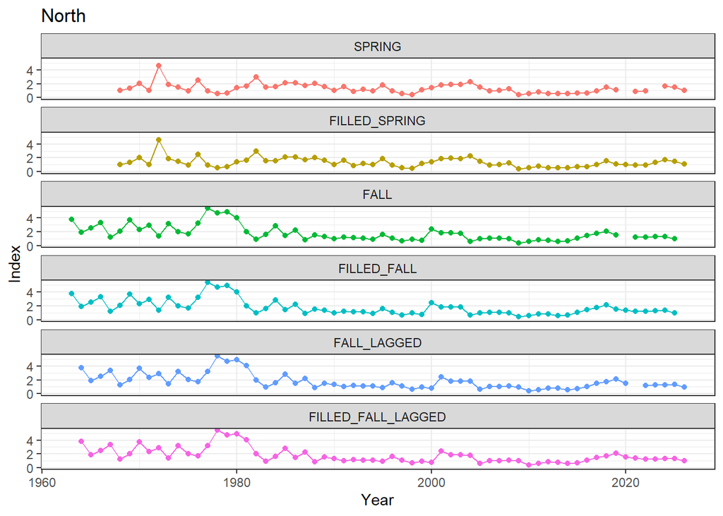

```r
plot_6_ts(north, "North")
```

**South**

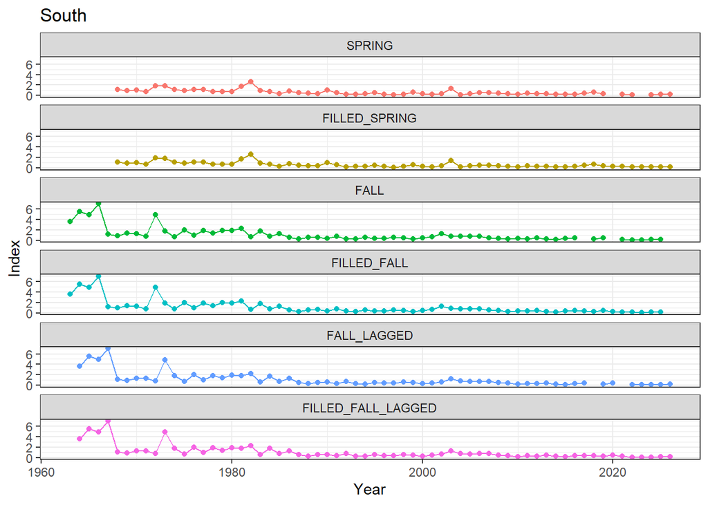

```r
plot_6_ts(south, "South")
```

### Step 2 Calculated Multipliers

Since there are missing surveys for both monkfish stocks, we will calculate Ismooth multipliers using both the filled and missing treatments of these missing surveys. To generalize the code and improve workflows, we first determine which is the most recent survey available in the csv files (we assume north and south stocks have the same latest survey).

```r
# check north data for which is the latest survey, assume the same for south
lastyear <- max(north$Year)
checkseason <- north |>
  filter(Year == lastyear)
lastseason <- ifelse(is.na(checkseason$Index[checkseason$Series == "FALL"]), "Spring", "Fall")
```

Before computing the multipliers, the surveys to be used have to be defined and an average computed. This can be done using the function `standardize_and_combine_indices()` to produce a list containing two tibbles. The first tibble adds the column Index_Standardized to the tibble that was sent to the function. The second tibble has columns Year and avg, this is the input for the Ismooth calclulations. The function `plot_standardized_and_avg()` can be used to visualize the results of the standardization and average step (see the Survey Average Plot tab in the figures below). A quirk of PlanBsmooth is that the standardization of each series is done using all the years supplied, even if there are more than the 33 years used in the loess smooth. Since the averaging of multiple surveys will depend on the year range of each survey, this can produce unexpected results (see Time Period for Averages section below). For this document, the average value is NA when either the spring or lagged fall survey is NA due to the mynarm setting of FALSE (as is the default in the `ApplyPlanBsmooth()` function). You may wish to explore whether setting mynarm to TRUE produces improved fill test results (left as an exercise for the interested reader).

Once the tibble with Year and avg is created, the PlanBsmooth package function `ApplyPlanBsmooth()` can be used to compute the multiplier and create the standard plot. The function `wrapIsmooth()` is provided to combine these three steps into one function to make workflows easier. The code below shows how to do each of the three steps by hand and then compares the results to using the wrapper function for the north filled scenario.

```r
# here we do the three steps by hand
myyearstart <- 1964
myyearend <- lastyear
myseries <- c("FILLED_SPRING", "FILLED_FALL_LAGGED")
mytitle <- paste("North Filled", lastyear)

north_fill_sadata <- standardize_and_combine_indices(north, myyearstart, myyearend, myseries)

north_sap <- plot_standardized_and_avg(north_fill_sadata, mytitle)
# print(north_sap) # not shown here, uncomment this line to see the plot

north_fill_Ismoothres <- ApplyPlanBsmooth(north_fill_sadata$avg, my.title = mytitle, showplots = FALSE)

# here the wrapper function is used defining all the variables
nlastfill <- wrapIsmooth(data = north,
                         YearStart = 1964,
                         YearEnd = lastyear,
                         myseries = c("FILLED_SPRING", "FILLED_FALL_LAGGED"),
                         mytitle = paste("North Filled", lastyear),
                         mynarm = FALSE,
                         print_plots = FALSE)

# compare the multipliers
comp_nf_mults <- tibble(Scenario = "North Filled",
                        Approach = c("By Hand", "Wrapper"),
                        Multiplier = c(north_fill_Ismoothres$multiplier, nlastfill$Ismooth$multiplier))

knitr::kable(comp_nf_mults)
```

| Scenario | Approach | Multiplier |
| --- | --- | --- |
| North Filled | By Hand | 0.9444723 |
| North Filled | Wrapper | 0.9444723 |

The multiplier values are the same, as expected. Note that Ismooth multipliers are typically rounded to three significant digits. The full digits are shown in the table above just to confirm that exactly the same results are produced by hand and using the wrapper function.

Now we can examine the south filled, north missing, and south missing scenarios using the wrapper function without the variable names and the defaults of na.rm=FALSE and not printing the plots. Instead of printing the plots automatically, as one would often do in exploratory analyses, here the tabset feature of Quarto is used to make a nice display using the results from the wrapped function calls. All the results from the PlanBsmooth function call are included in the wrapped function returned list, along with the tibbles and the survey average plot.

```r
slastfill <- wrapIsmooth(south, 1964, lastyear, c("FILLED_SPRING", "FILLED_FALL_LAGGED"),
                         paste("South Filled", lastyear))
nlastmiss <- wrapIsmooth(north, 1964, lastyear, c("SPRING", "FALL_LAGGED"), paste("North Missing", lastyear))
slastmiss <- wrapIsmooth(south, 1964, lastyear, c("SPRING", "FALL_LAGGED"), paste("South Missing", lastyear))
```

**Multiplier Plot**

**North Filled**

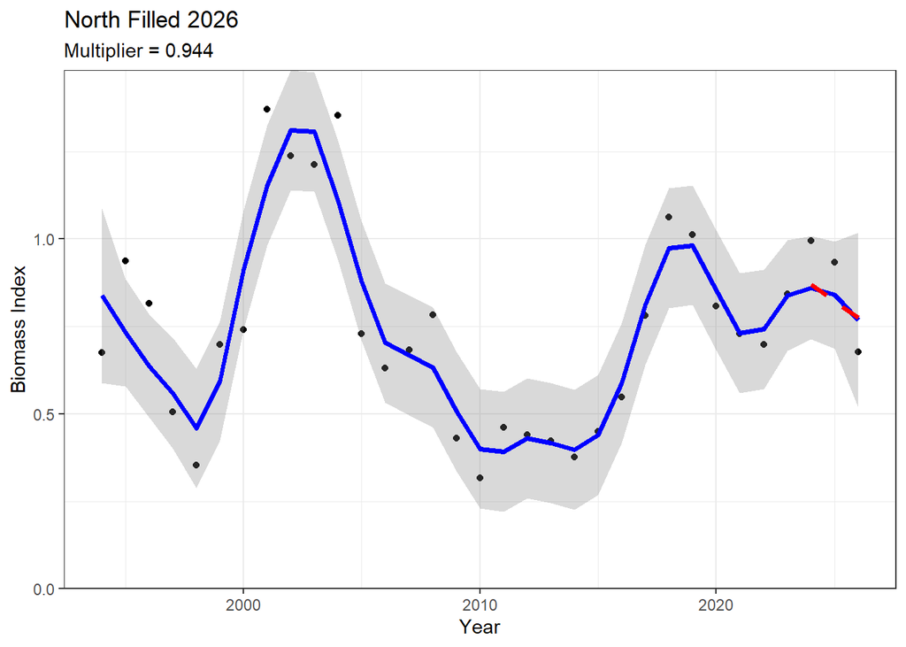

```r
print(nlastfill$Ismooth$tsplot)
```

**North Missing**

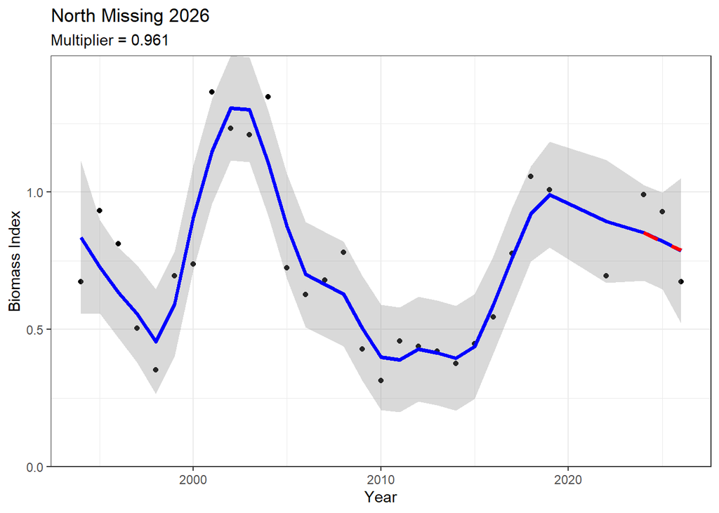

```r
print(nlastmiss$Ismooth$tsplot)
```

**South Filled**

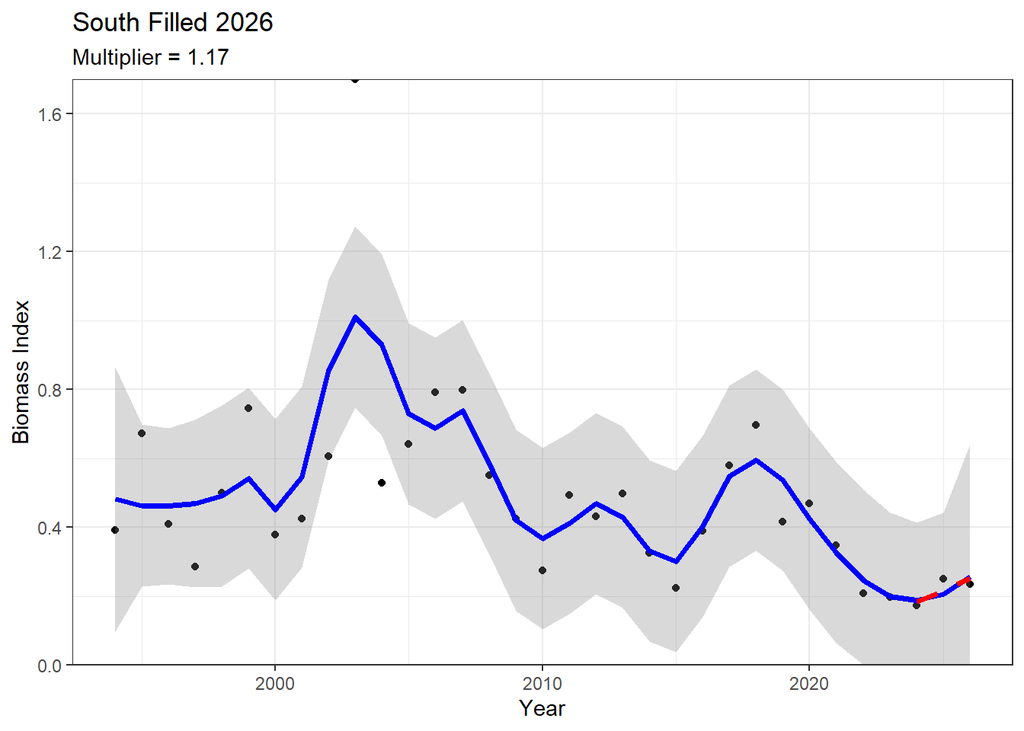

```r
print(slastfill$Ismooth$tsplot)
```

**South Missing**

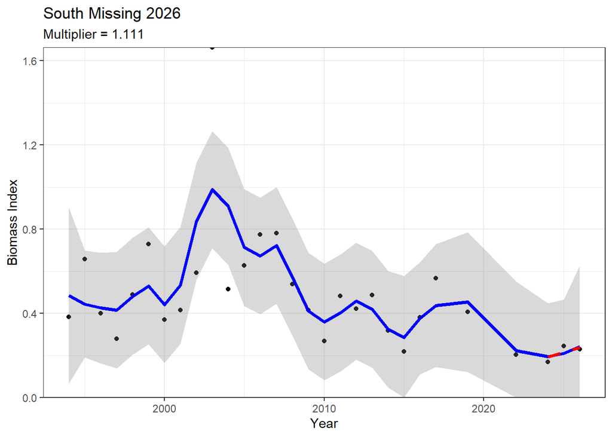

```r
print(slastmiss$Ismooth$tsplot)
```

**Survey Average Plot**

**North Filled**

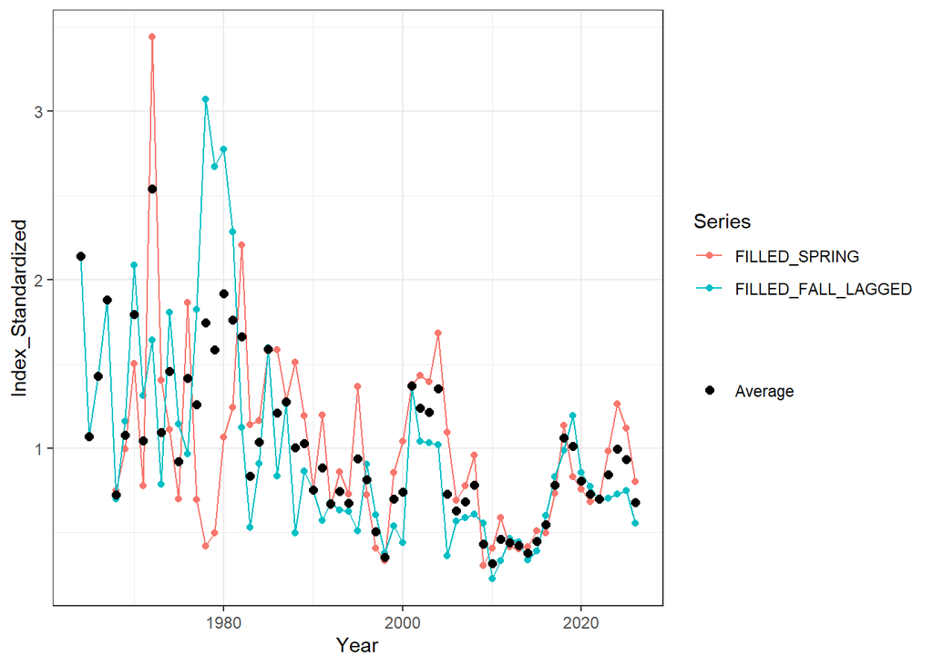

```r
print(nlastfill$sap)
```

**North Missing**

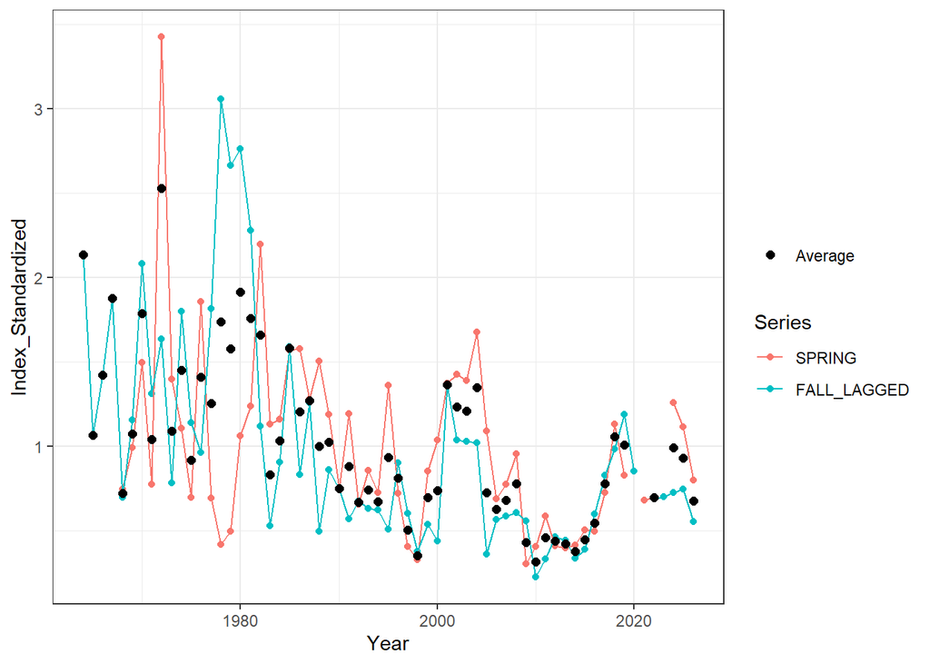

```r
print(nlastmiss$sap)
```

**South Filled**

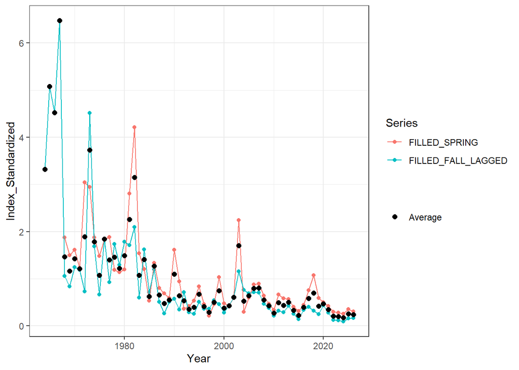

```r
print(slastfill$sap)
```

**South Missing**

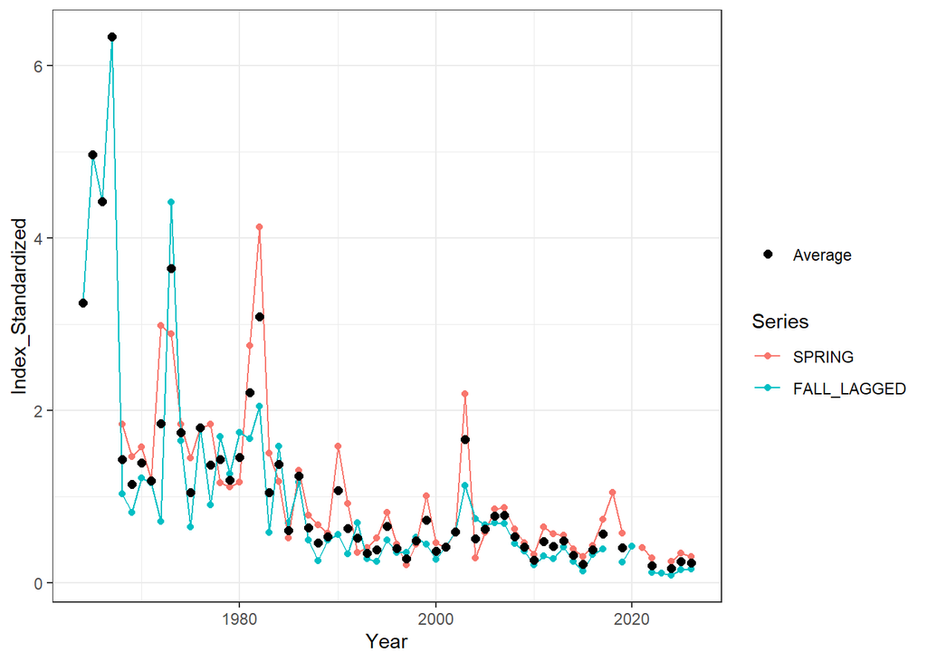

```r
print(slastmiss$sap)
```

The comparison table below shows the multiplier for both stocks of monkfish using filled and missing treatments for missing or incomplete surveys.

```r
compdf <- tibble(Stock = rep(c("North", "South"), each = 2),
                 Treatment = rep(c("Filled", "Missing"), 2),
                 Multiplier = round(c(nlastfill$Ismooth$multiplier, nlastmiss$Ismooth$multiplier,
                                      slastfill$Ismooth$multiplier, slastmiss$Ismooth$multiplier), 3))

knitr::kable(compdf)
```

| Stock | Treatment | Multiplier |
| --- | --- | --- |
| North | Filled | 0.944 |
| North | Missing | 0.961 |
| South | Filled | 1.170 |
| South | Missing | 1.111 |

If the filled and missing treatments produce the same multiplier, then you are all set. However, if the multipliers from the two treatments differ, as is the case for both monkfish stocks shown here, then you need to pick one. This is where the the fill test can be used.

### Step 3 Fill Test

One aspect of Ismooth that can be examined empirically is whether or not to fill missing survey values. While this is not a fully rigorous test due to the subjective choice of how many years to examine and how to determine which treatment is better, it can provide guidance for a given situation. The treatments available are to either leave the missing surveys as missing or to fill the missing surveys, typically with an average of the previous and subsequent survey value. The empirical test can be made by selecting a time period with no missing surveys and then removing surveys in the same manner as encountered in your current situation for a range of time periods. For example, if the final year in your Ismooth analysis is 2026 and you have all survey data available from 1968-2019, then a series of Ismooths can be run with terminal years ending in 1990 through 2019. Note that Ismooth can use less than the full 33 years of data when computing the loess smooth, but that the multiplier estimates can become unstable when the time series becomes too short (less than about 10 years). Users need to balance number of comparisons with loess stability when conducting the fill test.

This approach was originally applied to Georges Bank cod during the 2021 management track assessment. It used 10 terminal years ranging from 2020 to 2011 and a modification of the retro function in the PlanBsmooth package to make the comparison. This work was documented [here](https://github.com/cmlegault/PlanBsmooth_missing_data).

For monkfish, Jon Deroba conducted a similar exercise during the 2022 management track and concluded that filling the missing surveys was better for the southern stock and that there was no real difference for the northern stock. Based on these findings, it was decided to fill the missing surveys for both stocks of monkfish (NEFSC (2022)).

Two functions are provided here to ease the fill test and provide additional results to help make the decision whether to fill missing surveys. The `filltest()` function conducts the analysis while `plot_filltest()` provides three plots and a summary statistic to help make the choice. As noted above, while root mean square error metrics are provided for the filled and missing treatments, these values depend on the specific time periods used for comparisons, both how many and which ones. The results will change as the final year of the current Ismooth changes due to the relative position of the missing surveys to the terminal year in the analysis. So this analysis should be conducted each assessment to see if the previous decision still holds under the new conditions.

To see where the missing surveys are, the spring and lagged_fall series are shown below for recent years.

```r
recentyears_n <- north |>
  filter(Series %in% c("SPRING", "FALL_LAGGED")) |>
  pivot_wider(names_from = Series, names_prefix = "North_", values_from = Index) |>
  filter(Year >= 2016)

recentyears_s <- south |>
  filter(Series %in% c("SPRING", "FALL_LAGGED")) |>
  pivot_wider(names_from = Series, names_prefix = "South_", values_from = Index) |>
  filter(Year >= 2016)

recentyears <- recentyears_n |>
  left_join(recentyears_s, by="Year") |>
  mutate(relYear = Year - max(Year))

knitr::kable(recentyears)
```

| Year | North_SPRING | North_FALL_LAGGED | South_SPRING | South_FALL_LAGGED | relYear |
| --- | --- | --- | --- | --- | --- |
| 2016 | 0.6694 | 1.0588 | 0.2740 | 0.3643 | -10 |
| 2017 | 0.9817 | 1.4708 | 0.4661 | 0.4358 | -9 |
| 2018 | 1.5277 | 1.7464 | 0.6615 | NA | -8 |
| 2019 | 1.1198 | 2.1099 | 0.3634 | 0.2657 | -7 |
| 2020 | NA | 1.5151 | NA | 0.4706 | -6 |
| 2021 | 0.9202 | NA | 0.2588 | NA | -5 |
| 2022 | 0.9460 | 1.2224 | 0.1832 | 0.1322 | -4 |
| 2023 | NA | 1.2406 | NA | 0.1263 | -3 |
| 2024 | 1.6959 | 1.2865 | 0.1584 | 0.0955 | -2 |
| 2025 | 1.5028 | 1.3245 | 0.2162 | 0.1655 | -1 |
| 2026 | 1.0762 | 0.9808 | 0.1900 | 0.1782 | 0 |

```r
set.seed(14) # for reproducability of jitter plots

myfilltests_n <- tibble(relYear = c(-3, -6, -5),
                        Series = c("SPRING", "SPRING", "FILLED_FALL_LAGGED"),
                        Howfill = c("avg", "avg", "avg"))

northfilltest <- filltest(north, 1968, 1987, 2019, c("SPRING", "FILLED_FALL_LAGGED"), myfilltests_n)
northfilltest_plots <- plot_filltest(northfilltest, "North", FALSE)
```

The southern monkfish data have an additional missing survey, Fall 2017, so this is included in the myfilltests_s object before making the comparisons. Note that the south stock fill test is limited to years 1987 through 2017 because the fall 2017 value is lagged to 2018.

```r
myfilltests_s <- myfilltests_n |>
  add_row(relYear = -8, Series = "FILLED_FALL_LAGGED", Howfill = "avg")

southfilltest <- filltest(south, 1968, 1987, 2017, c("SPRING", "FILLED_FALL_LAGGED"), myfilltests_s)
southfilltest_plots <- plot_filltest(southfilltest, "South", FALSE)
```

**North**

**XY Plot**

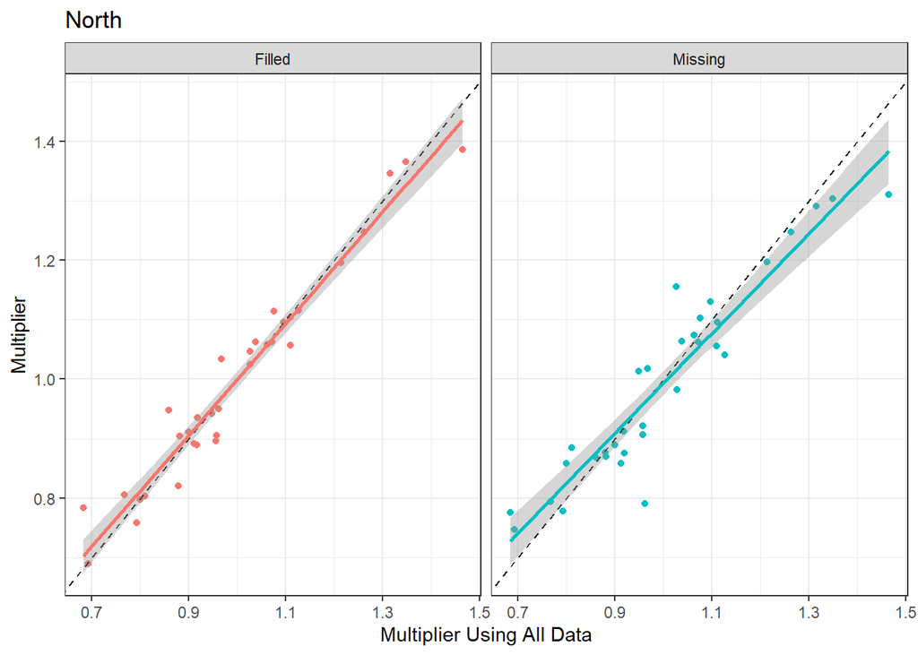

```r
print(northfilltest_plots$p1)
```

**Difference Distribution Plot**

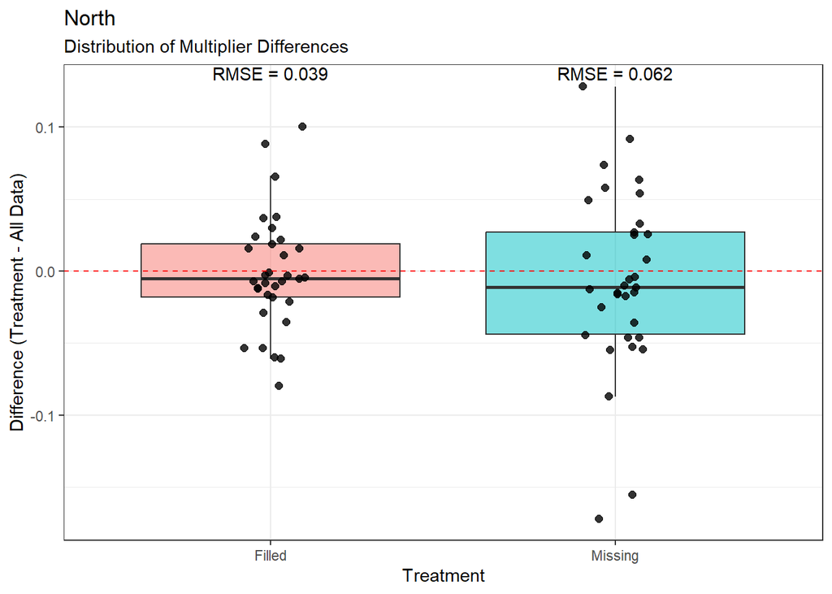

```r
print(northfilltest_plots$p2)
```

**Difference Time Series Plot**

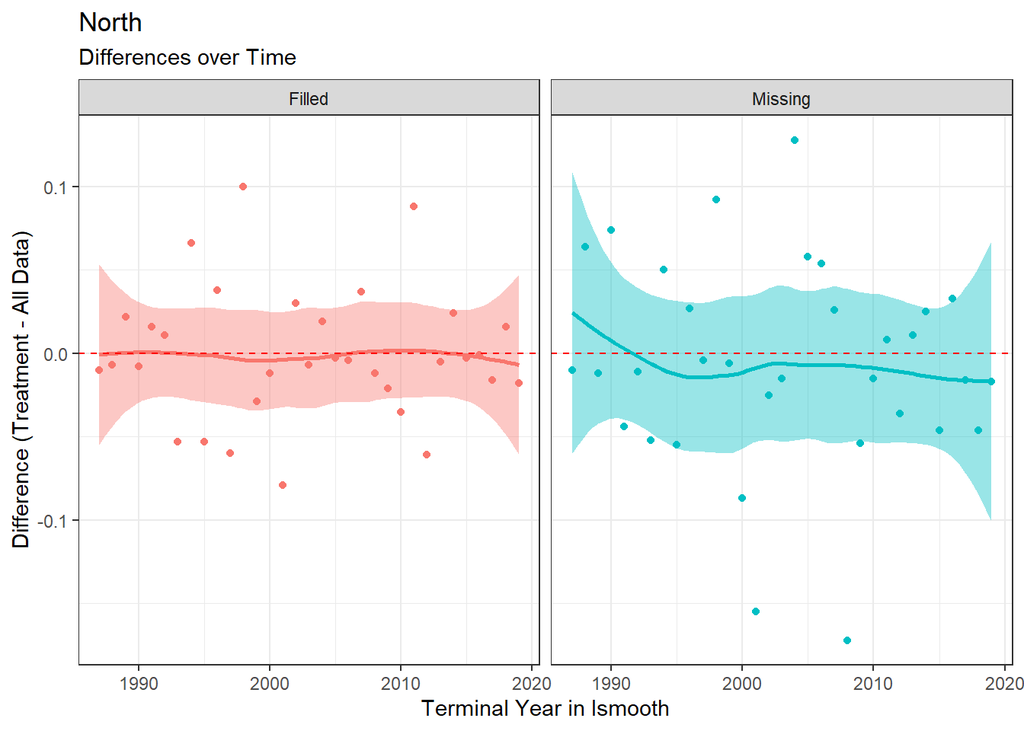

```r
print(northfilltest_plots$p3)
```

**South**

**XY Plot**

[figure not shown]

```r
print(southfilltest_plots$p1)
```

**Difference Distribution Plot**

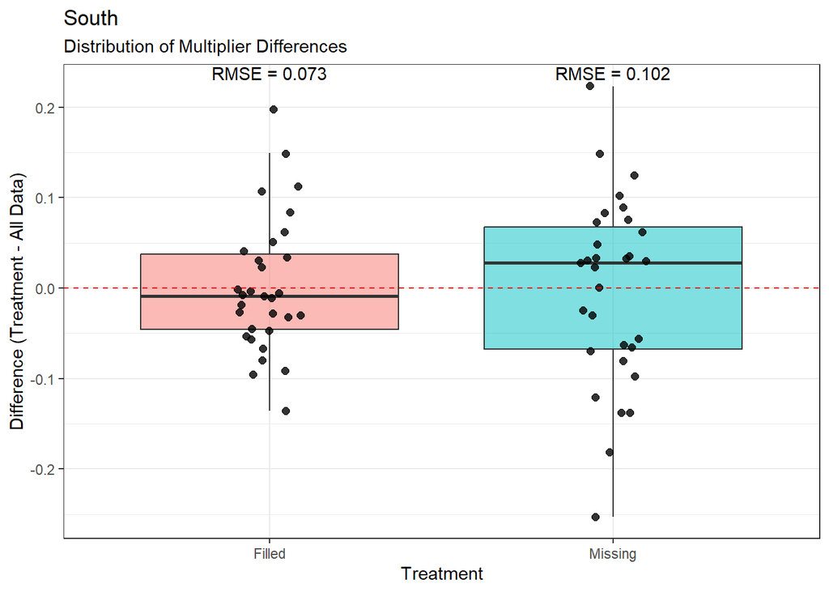

```r
print(southfilltest_plots$p2)
```

**Difference Time Series Plot**

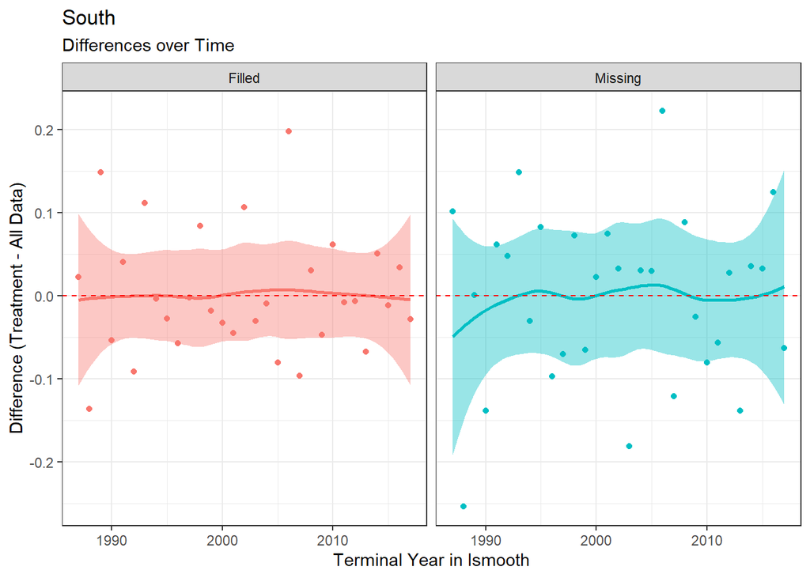

```r
print(southfilltest_plots$p3)
```

The results for northern monkfish cause me to lean toward the Filled approach. In the scatter plot of multipliers by treatment against using all the data, the fit line for Filled is closer at low and high multipliers compared to the Missing treatment. The inner-quartile distribution of differences in the multipliers is tighter and closer to zero for Filled compared to Missing, with a lower root mean squared error (RMSE) in the Difference Distribution plot. The time series plots of differences in multipliers by treatment shows less time trend for Filled than Missing based on the smoothed curve shown in each panel. I welcome suggestions for other ways to plot or analyze these results.

The results for southern monkfish also indicate to me a preference for treating the missing surveys as filled as well. This is because the XY plot shows a tighter match to the one-to-one line, the Difference Distribution plot shows a smaller RMSE and tighter distribution of differences around zero, and the time series of differences shows the smoothed line closer to zero.

While neither stock shows a definitive winner between the treatments, there is in my opinion a basis to select the Filled approach for both the northern and southern monkfish stocks in this new situation of missing values. When the next assessment is conducted, the relative number of years from the terminal year for these missing surveys will have changed. Hopefully, there will not be any new missing surveys.

### Step 4 Apply to Recent Catch

Monkfish have only commercial landings and discards. Recreational catch is considered too small to include in the assessment and Canadian catch is not included. So, the recent catch can be easily grabbed from StockEff. The average of the recent three years is the basis for the mean catch value. Multiplying the mean catch by the multiplier results in the catch advice. In the time series plot below, the final year is a partial year of catch.

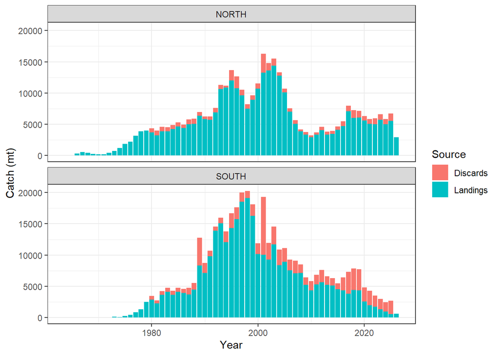

```r
nland <- read.csv(file.path(monkpath, "STOCKEFF_CF_164499_NORTH_NONE_total_landings.csv"))
sland <- read.csv(file.path(monkpath, "STOCKEFF_CF_164499_SOUTH_NONE_total_landings.csv"))
ndisc <- read.csv(file.path(monkpath, "STOCKEFF_OB_164499_NORTH_NONE_ob_timeseries_plot.csv"))
sdisc <- read.csv(file.path(monkpath, "STOCKEFF_OB_164499_SOUTH_NONE_ob_timeseries_plot.csv"))

lyear <- 2025
fyear <- lyear - 2 # get three years

landings <- rbind(nland, sland) |>
  select(STOCK_ABBREV, YEAR, LANDINGS_MT)

discards <- rbind(ndisc, sdisc) |>
  select(STOCK_ABBREV, YEAR, DADJMT)

lddata <- landings |>
  left_join(discards, by = c("YEAR", "STOCK_ABBREV")) |>
  rename(Landings = LANDINGS_MT, Discards = DADJMT)

lddatalong <- lddata |>
  pivot_longer(cols = c(Landings, Discards), names_to = "Source", values_to = "Value")

p1 <- ggplot(lddatalong, aes(x=YEAR, y=Value, fill=Source)) +
  geom_col() +
  facet_wrap(~STOCK_ABBREV, ncol =1) +
  xlab("Year") +
  ylab("Catch (mt)") +
  theme_bw()
print(p1)
```

```r
catch <- lddata |>
  mutate(Catch_MT = Landings + Discards) |>
  filter(YEAR %in% fyear:lyear)

knitr::kable(catch)
```

| STOCK_ABBREV | YEAR | Landings | Discards | Catch_MT |
| --- | --- | --- | --- | --- |
| NORTH | 2023 | 5694.767 | 921.6384 | 6616.405 |
| NORTH | 2024 | 5017.079 | 845.2762 | 5862.355 |
| NORTH | 2025 | 5515.779 | 1239.1431 | 6754.922 |
| SOUTH | 2023 | 1351.955 | 1632.2385 | 2984.194 |
| SOUTH | 2024 | 940.326 | 1519.0367 | 2459.363 |
| SOUTH | 2025 | 580.447 | 2092.9042 | 2673.351 |

```r
meancatch <- catch |>
  group_by(STOCK_ABBREV) |>
  summarize(meancatch = mean(Catch_MT, na.rm = TRUE)) |>
  mutate(FYear = fyear, LYear = lyear)

knitr::kable(meancatch)
```

| STOCK_ABBREV | meancatch | FYear | LYear |
| --- | --- | --- | --- |
| NORTH | 6411.228 | 2023 | 2025 |
| SOUTH | 2705.636 | 2023 | 2025 |

As noted above, the catch advice (ABC specifically), is calculated as the mean of the recent three years of catch times the multiplier, by stock. In this example, with the last year of survey data of 2026 and mean catch for years 2023 through 2025, the catch advice would be for 2027 through 2029.

```r
ca <- tibble(Stock = c("North", "South"),
             Treatment = c("Filled", "Filled"),
             Multiplier = c(round(nlastfill$Ismooth$multiplier, 3),
                            round(slastfill$Ismooth$multiplier, 3)),
             MeanCatch = meancatch$meancatch) |>
  mutate(ABC = round(Multiplier * MeanCatch, 0))

knitr::kable(ca)
```

| Stock | Treatment | Multiplier | MeanCatch | ABC |
| --- | --- | --- | --- | --- |
| North | Filled | 0.944 | 6411.228 | 6052 |
| South | Filled | 1.170 | 2705.636 | 3166 |

A final summary plot shows the catch since 2000, as above, but with the mean catch used in Ismooth shown as a black horizontal line and the ABC shown as a red horizontal line.

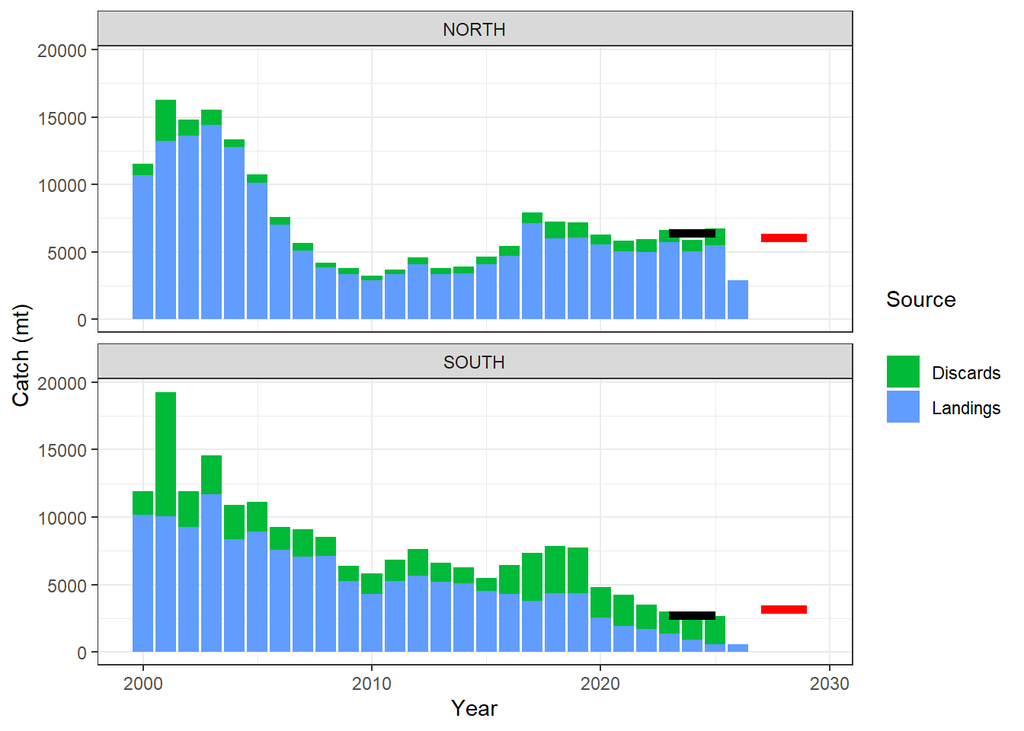

```r
cadfn <- tibble(STOCK_ABBREV = "NORTH",
                YEAR=fyear:(lyear+4),
                Source = "",
                MeanCatch = c(rep(meancatch$meancatch[1], 3), rep(NA, 4)),
                ABC = c(rep(NA, 4), rep(ca$ABC[1], 3)))

cadfs <- tibble(STOCK_ABBREV = "SOUTH",
                YEAR=fyear:(lyear+4),
                Source = "",
                MeanCatch = c(rep(meancatch$meancatch[2], 3), rep(NA, 4)),
                ABC = c(rep(NA, 4), rep(ca$ABC[2], 3)))

cadf <- rbind(cadfn, cadfs)

p2 <- p1 +
  geom_line(data=cadf, aes(x=YEAR, y=MeanCatch), color="black", linewidth=2) +
  geom_line(data=cadf, aes(x=YEAR, y=ABC), color = "red", linewidth=2) +
  xlim(c(1999.5, lyear+4.5))
print(p2)
```

This concludes the standard workflow section. The following sections provide additional food for thought when using Ismooth.

## Confirm Previous Results

It is good practice to build a bridge from the previous assessment. In this case, it is simply showing that the previous multipliers estimated in the 2022 assessment can be replicated using the wrapper function and the recent StockEff files (which have more years of data than were available during the 2022 assessment).

The plots below show how restricting the data to 1964-2022 allows full replication of the 2022 assessment results. The multipliers from the 2022 assessment were 0.829 in the North and 0.646 in the South.

```r
n2022 <- wrapIsmooth(north, 1964, 2022, c("FILLED_SPRING", "FILLED_FALL_LAGGED"), "North 2022")
s2022 <- wrapIsmooth(south, 1964, 2022, c("FILLED_SPRING", "FILLED_FALL_LAGGED"), "South 2022")
```

**Multiplier Plot**

**North Filled**

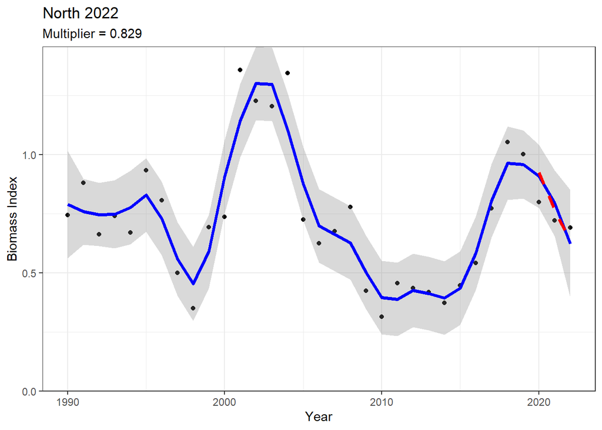

```r
print(n2022$Ismooth$tsplot)
```

**South Filled**

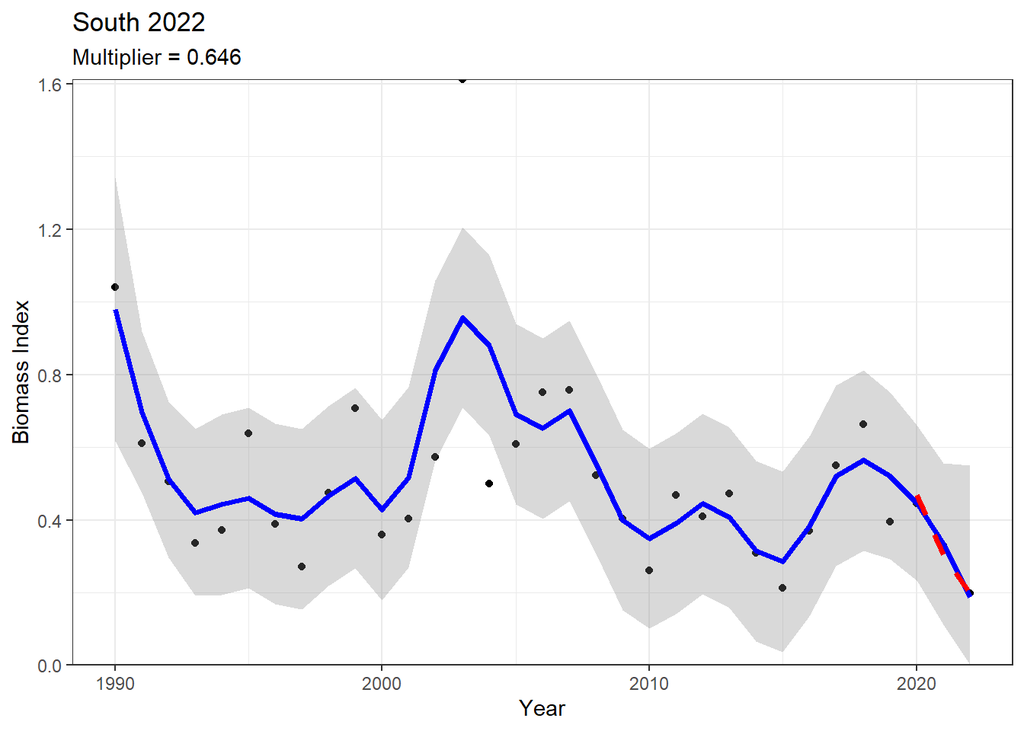

```r
print(s2022$Ismooth$tsplot)
```

**Survey Average Plot**

**North Filled**

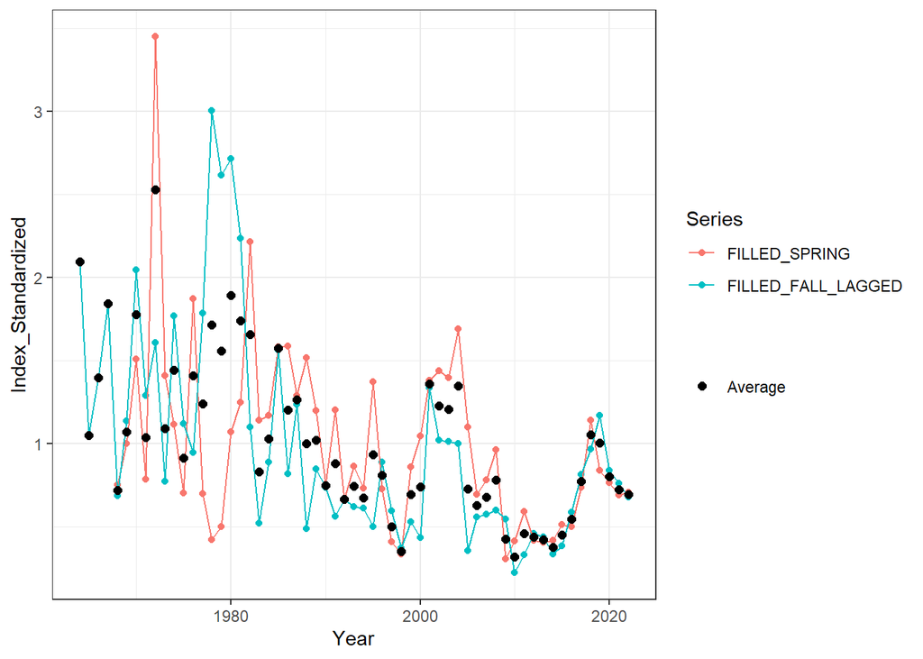

```r
print(n2022$sap)
```

**South Filled**

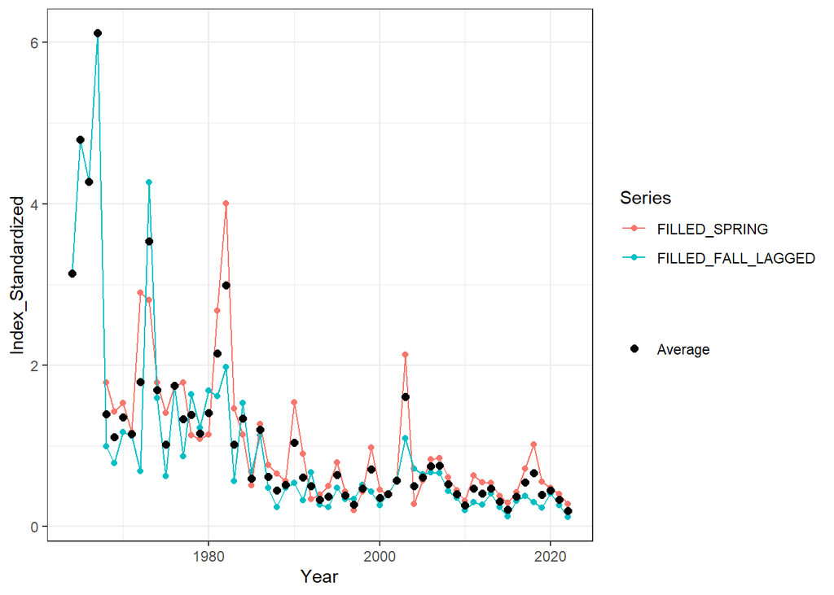

```r
print(s2022$sap)
```

```r
if (round(n2022$Ismooth$multiplier, 3) == 0.829){
  check_north <- TRUE
} else {
  check_north <- FALSE
}

if (round(s2022$Ismooth$multiplier, 3) == 0.646){
  check_south <- TRUE
} else {
  check_south <- FALSE
}

if (check_north == TRUE & check_south == TRUE){
  print("Both north and south match the 2022 assessment. Carry on")
} else {
  print("Something is wrong. Please check the values.")
  print(paste("check_north = ", check_north))
  print(paste("check_south = ", check_south))
}
```

```
[1] "Both north and south match the 2022 assessment. Carry on"
```

## Conduct Sensitivity Runs

This section demonstrates two types of sensitivity runs. The first examines the impact of removing an incomplete survey. It shows how the multiplier changes when the fall 2025 bottom trawl survey is replaced by the fall 2024 survey. It cannot be replaced by the average of the fall 2024 and 2026 surveys, yet, because the fall 2026 survey has not been conducted. There are no diagnostics within Ismooth that will help with the determination of whether to replace the fall 2025 survey with a filled value, that determination must be made using other information. This sensitivity can only show how the multiplier changes.

The second set of sensitivity runs shows how using different data, specifically the Bigelow only data either converted to total biomass using the results of the chainsweep experiment or just direct estimation (not calibrated to Albatross units) can change the multipliers. Reasons why these multipliers can differ are provided in each subsection.

### Sensitivity for Fall 2025 Survey

The Fall 2025 bottom trawl survey had a lower coverage rate than many other years, but still achieved at least two stations per strata. Some stocks have decided to not include it in their assessment (e.g., Georges Bank haddock), while other stocks have kept it in (e.g., herring). The stock lead would need to take a detailed look at the data to determine whether or not to recommend including it in the base analysis for their stock. Here we consider a sensitivity to see how much of a difference it makes for the north stock only, as the south stock had more typical coverage in Fall 25 than the north stock. Note that at the moment, the Fall 2026 survey is not available, so we use just the Fall 2024 survey to fill the Fall 2025 survey (using the “pre” option in the `fill_hole()` function). The code below adds a check to instead use the “avg” option when the Fall 26 bottom trawl survey is available. If the Fall 25 survey is considered non-representative for monkfish, then a fill test could be conducted including this missing value. This is left as an exercise for the interested reader.

```r
checkfall26 <- north |>
  filter(Year == 2026, Series == "FALL")

if (is.na(checkfall26$Index[1])){
  fillfall25 <- "pre"
} else {
  fillfall25 <- "avg"
}

myfills_northFall25 <- myfills_north |>
  add_row(Year = 2025, Series = "FALL", Howfill = fillfall25)

myfilename <- "STOCKEFF_SV_164499_NORTH_NONE_strat_mean.csv"
mydata <- read.csv(file.path(monkpath, myfilename))

northFall25 <- clean_stockeff_survey_data(mydata, mypurpose, myseasons, myindextype, myfills_northFall25)

# replace the Fall 25 survey (and lagged version) with NA for plotting
northFall25 <- northFall25 |>
  mutate(Index = case_when(
    Year == 2025 & Series == "FALL" ~ NA,
    Year == 2026 & Series == "FALL_LAGGED" ~ NA,
    .default = Index
  ))

YearStart <- 1964
YearEnd <- lastyear
myseries <- c("FILLED_SPRING", "FILLED_FALL_LAGGED")

nlastFall25 <- wrapIsmooth(northFall25, 1964, lastyear, c("FILLED_SPRING", "FILLED_FALL_LAGGED"),
                   paste("North", lastyear, "Fall 2025 Sensitivity"))
```

**Multiplier Plot**

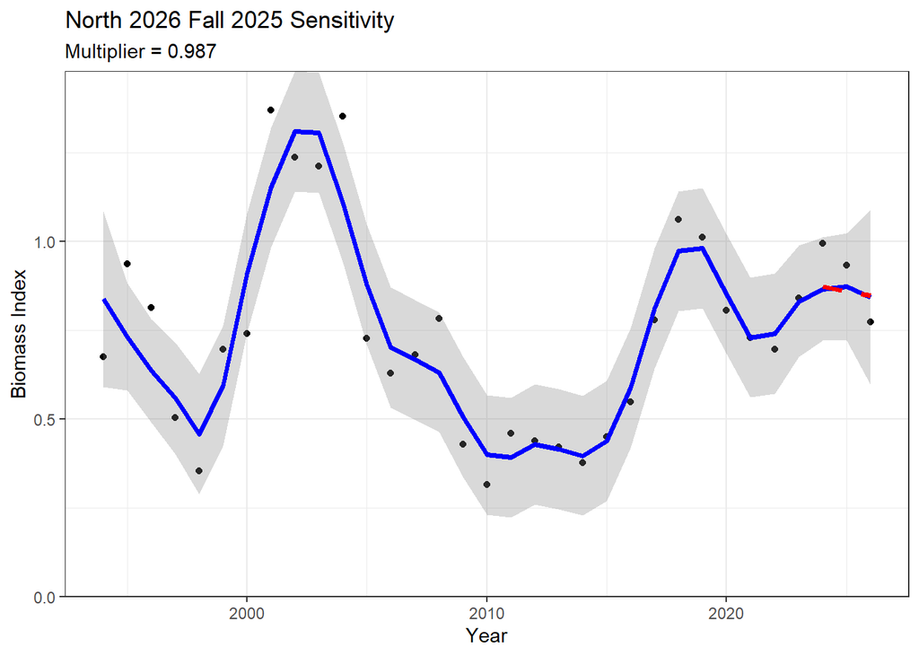

```r
print(nlastFall25$Ismooth$tsplot)
```

**Survey Average Plot**

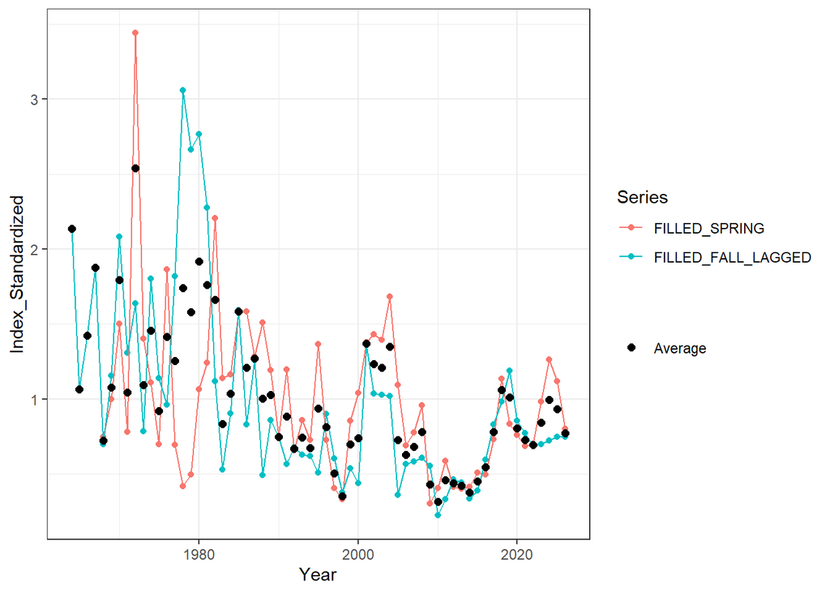

```r
print(nlastFall25$sap)
```

**6 Panel Plot**

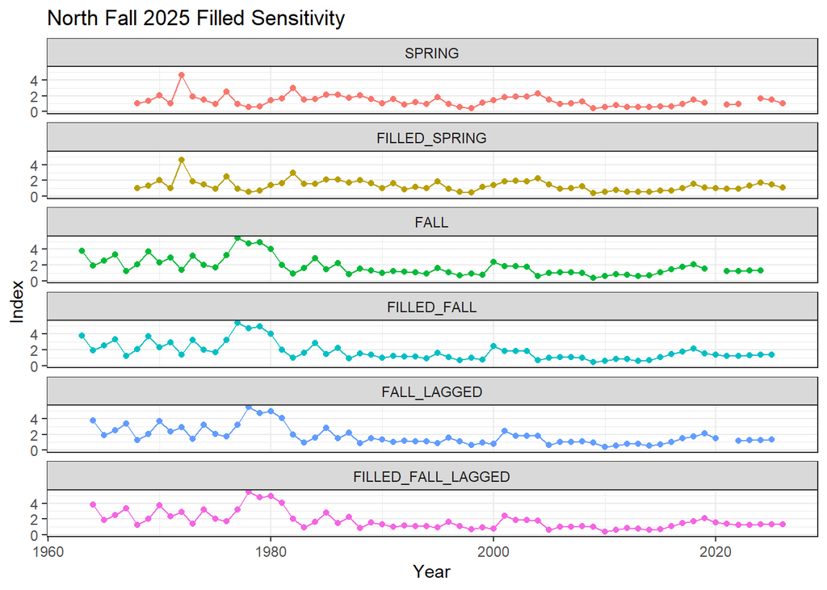

```r
plot_6_ts(northFall25, "North Fall 2025 Filled Sensitivity")
```

The Fall 2025 bottom trawl survey sensitivity used the pre option to fill the incomplete survey and has a 4.56% relative change in the multiplier compared to the original value.

Multipliers:

- sens = 0.987
- orig = 0.944

### Chainsweep Sensitivity

Tim Miller led the development of applying the results of the chainsweep experiment to estimate population biomass in metric tons for the Bigelow years for the flatfish and some other species, including both stocks of monkfish (Miller *et al.* (2023)). These estimates are only applicable to the Bigelow years, 2009 onward. The approach used here modifies Tim’s csv file of biomass to be similar enough to the StockEff file that the functions can be applied directly. Note that Tim’s csv files contain estimates for the spring 2023 survey, but not the spring or fall 2020 surveys. The same surveys that were filled originally are filled here.

```r
# mutate Tim's csv file so can pass to standardize and combine function

mystock <- "north_goose"
stock_file <- paste0(mystock, ".biomass.csv")
filename <- paste0("\\\\nefscdata\\Chainsweep_Biomass\\chainsweep_biomass\\results\\standardized\\", stock_file)
Tim_north <- read.csv(filename) |>
  rename(YEAR = X,
         FALL = fall,
         SPRING = spring) |>
  add_row(YEAR = 2020, FALL = NA, SPRING = NA) |>
  arrange(YEAR) |>
  pivot_longer(cols = !YEAR, names_to = "SEASON", values_to = "INDEX") |>
  mutate(PURPOSE_CODE = 10,
         INDEX_TYPE = "Biomass_mt") |>
  arrange(SEASON, YEAR)

mydata <- Tim_north
chainindextype <- "Biomass_mt"

northchain <- clean_stockeff_survey_data(mydata, mypurpose, myseasons, chainindextype, myfills_north)

nchainlast <- wrapIsmooth(northchain, 2009, lastyear, c("FILLED_SPRING", "FILLED_FALL_LAGGED"),
                  paste("North Chainsweep", lastyear))

mystock <- "south_goose"
stock_file <- paste0(mystock, ".biomass.csv")
filename <- paste0("\\\\nefscdata\\Chainsweep_Biomass\\chainsweep_biomass\\results\\standardized\\", stock_file)
Tim_south <- read.csv(filename) |>
  rename(YEAR = X,
         FALL = fall,
         SPRING = spring) |>
  add_row(YEAR = 2020, FALL = NA, SPRING = NA) |>
  arrange(YEAR) |>
  pivot_longer(cols = !YEAR, names_to = "SEASON", values_to = "INDEX") |>
  mutate(PURPOSE_CODE = 10,
         INDEX_TYPE = "Biomass_mt") |>
  arrange(SEASON, YEAR)

mydata <- Tim_south

southchain <- clean_stockeff_survey_data(mydata, mypurpose, myseasons, chainindextype, myfills_south)

schainlast <- wrapIsmooth(southchain, 2009, lastyear, c("FILLED_SPRING", "FILLED_FALL_LAGGED"),
                  paste("South Chainsweep", lastyear))
```

**North**

**Multiplier Plot**

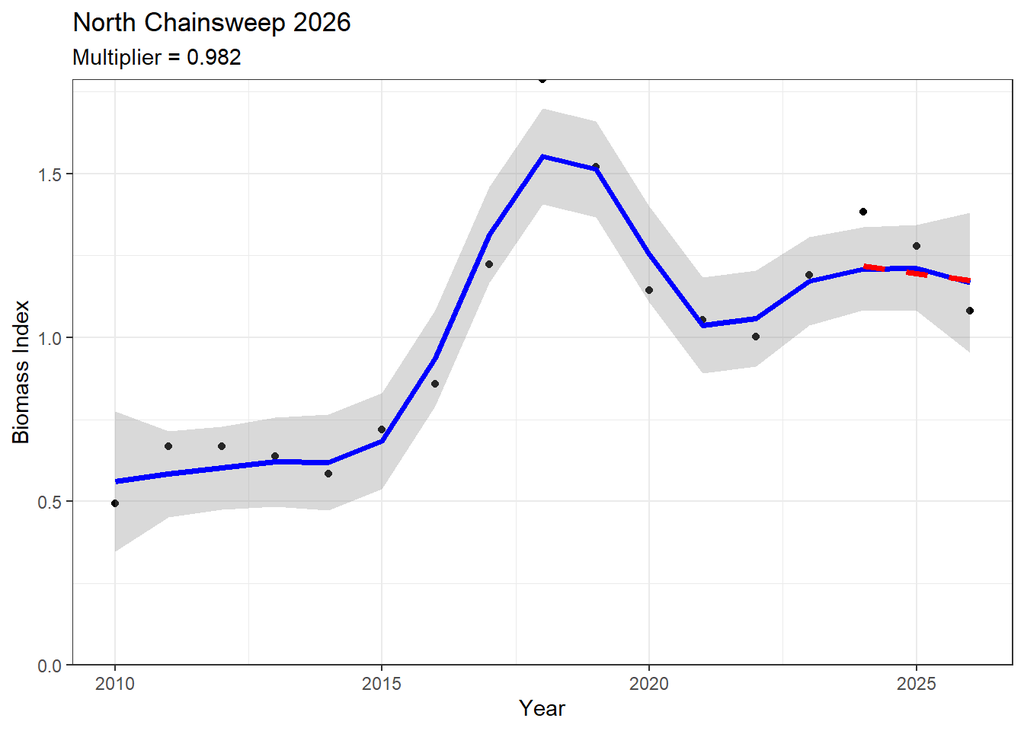

```r
print(nchainlast$Ismooth$tsplot)
```

**Survey Average Plot**

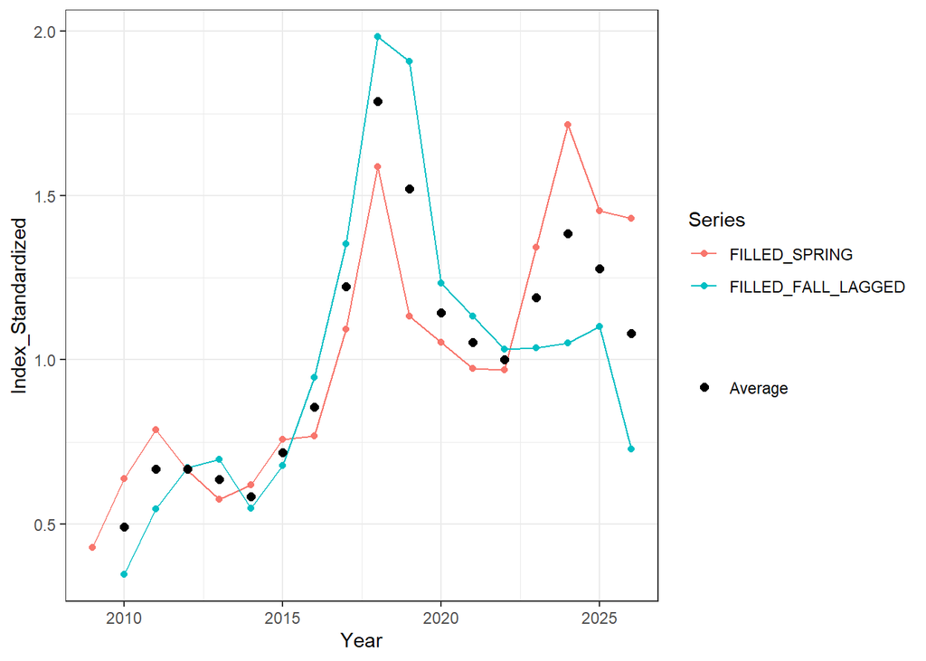

```r
print(nchainlast$sap)
```

**6 Panel Plot**

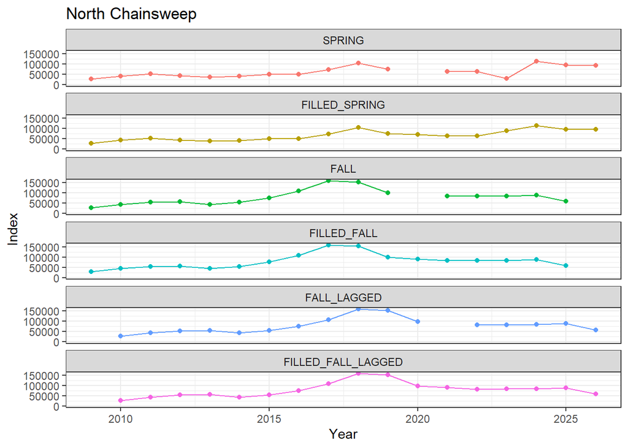

```r
plot_6_ts(northchain, "North Chainsweep")
```

**South**

**Multiplier Plot**

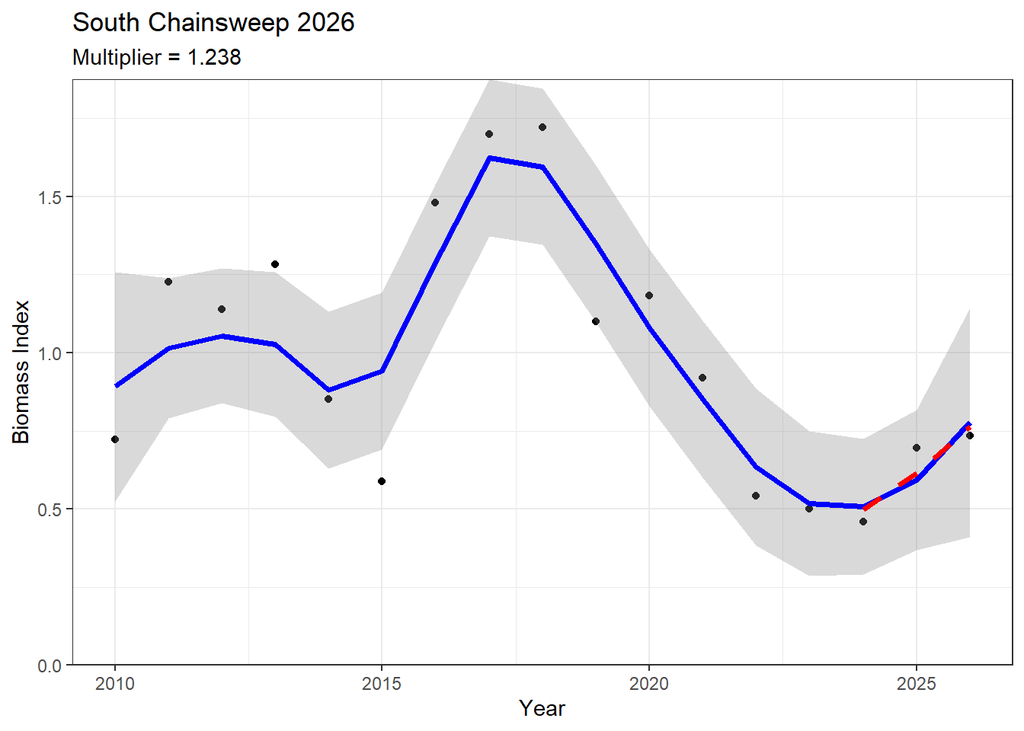

```r
print(schainlast$Ismooth$tsplot)
```

**Survey Average Plot**

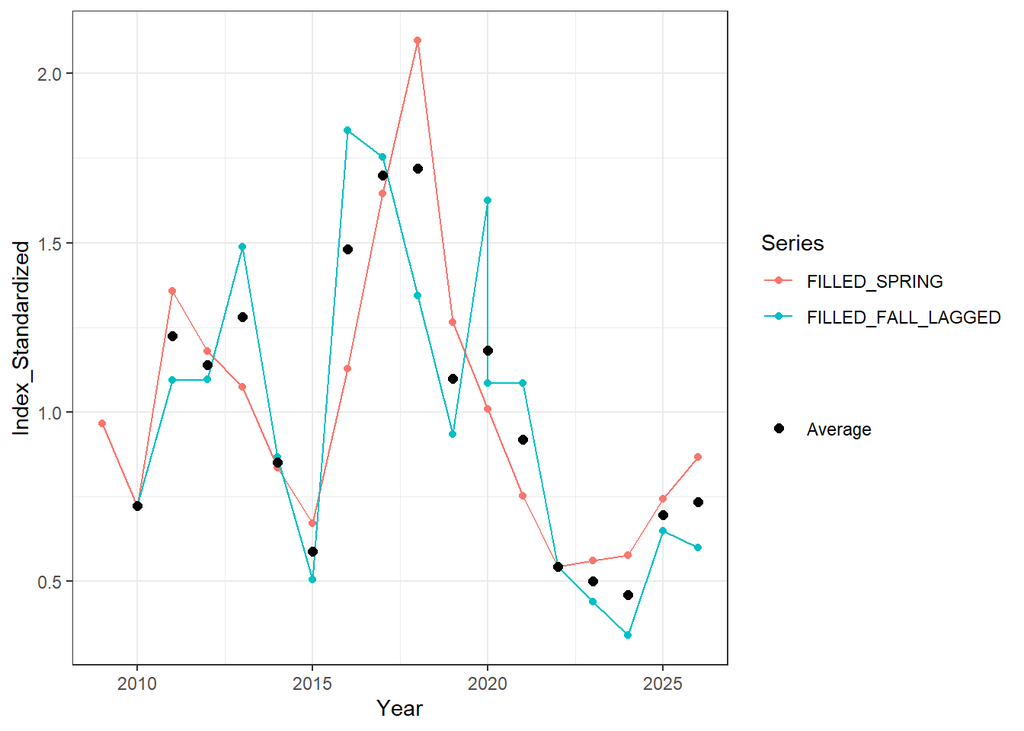

```r
print(schainlast$sap)
```

**6 Panel Plot**

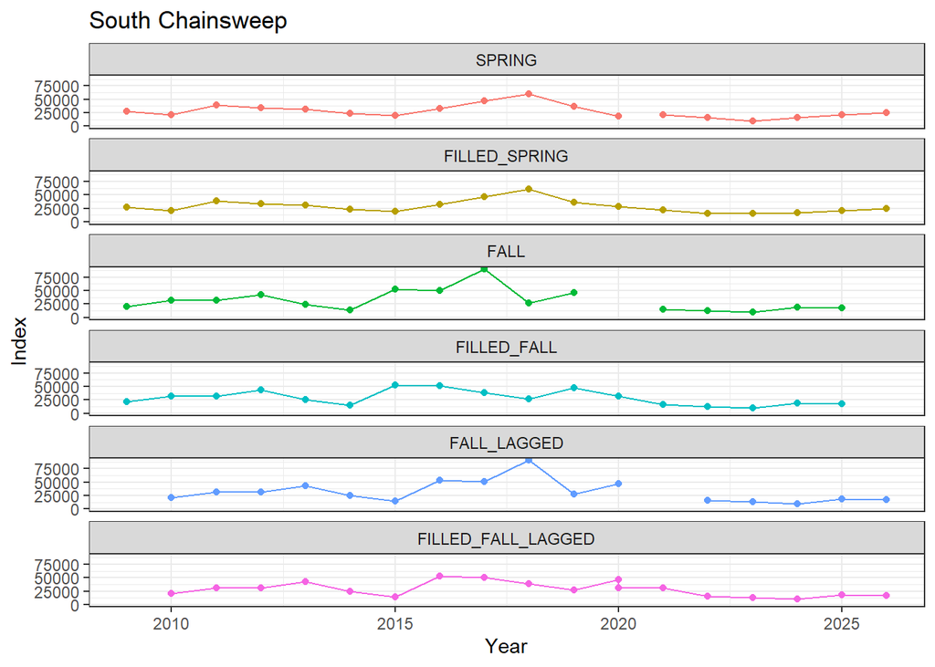

```r
plot_6_ts(southchain, "South Chainsweep")
```

Due to the short time period of the Bigelow survey, and the timing of the missing surveys, there is insufficient information to make a reasonable determination between filling and missing treatments. So no fill test is conducted here or for the uncalibrated Bigelow time series.

The multiplier differences are due to the chainsweep estimates having a slightly different trend compared to the stratified means. This is due to the length-based calibration used in the chainsweep expansion that varies each year depending on the length distribution of the fish caught in that survey.